# Dissertation Analysis: Correlations - Time Remaining (Individual)- Team Orientation

Jamiahus Walton

2019-06-29

# Motivation

The motivation behind this analysis is to discover different correlations between participants actual performance and self-reported performance. Significance was found in previous analysis regarding a sinificant difference in time remaining at the individual level and the goal of this analysis is to attempt to understand why there was significance.

**Note:** In TLX, a value of 0 for the performance channel is considered perfect and 100 is considered faile. This is because if you felt the you’re performance was perfect, then that would mean your task load was lower. For this analysis, performance was reverse coded so that 0 is failure and 100 is perfect.

# Is there correlation between a actual performance (i.e., Time Remaining) and self-reported performance (i.e, Performance (reverse) from TLX)?

## Time Remaining - timeRemaining_ind

### Plots and Stats

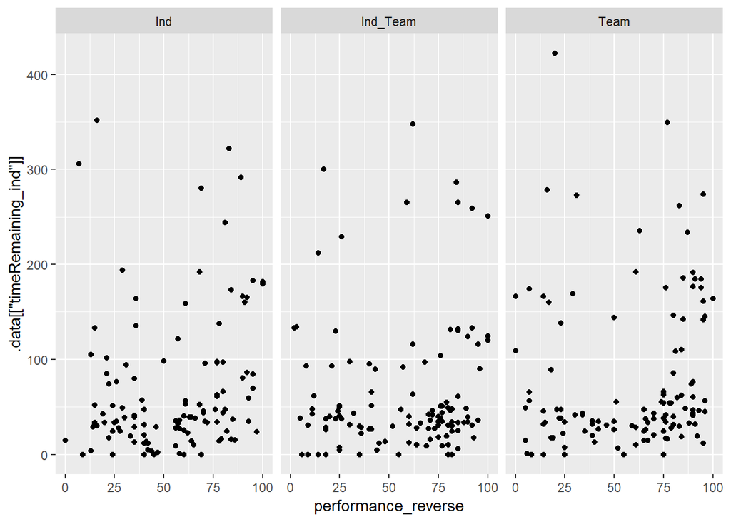

```r
# dependent<- "timeRemaining_ind"

plot_data_ind <- ind_data %>%
  select(Performance,
         params$dependent_response_ind,
         Target) %>%
  mutate(performance_reverse = 100 - Performance)

ggplot(data = plot_data_ind, aes(x = performance_reverse, y = .data[[params$dependent_response_ind]])) +
  geom_point() +
  facet_grid( . ~ Target)
```

No obious patterns. No obvious violation of monotonic relationship.

```r
# dependent<- "timeRemaining_ind"


for (my_target in c("Ind", "Team", "Ind_Team")) {

  plot_data_ind <- ind_data %>%
  select(Performance,
         params$dependent_response_ind,
         SessionOrder,
         Dominate.Strategy,
         My_Performance,
         Target,
         Player_ID) %>%
  mutate(performance_reverse = 100 - Performance) %>%
  filter(Target == my_target)

  N_paris<- length(plot_data_ind[[params$dependent_response_ind]])

  print(paste("Correltation: Condition =", my_target))

  print(paste("Pairs:", N_paris, ", Degree of Freedom:", N_paris-2))

  print(cor.test(y = plot_data_ind[[params$dependent_response_ind]], x = plot_data_ind[["performance_reverse"]], method = "spearman"))
  }
```

```
## [1] "Correltation: Condition = Ind"
## [1] "Pairs: 117 , Degree of Freedom: 115"
```

```
##
##  Spearman's rank correlation rho
##
## data:  plot_data_ind[["performance_reverse"]] and plot_data_ind[[params$dependent_response_ind]]
## S = 198150, p-value = 0.005041
## alternative hypothesis: true rho is not equal to 0
## sample estimates:
##       rho
## 0.2576432
##
## [1] "Correltation: Condition = Team"
## [1] "Pairs: 117 , Degree of Freedom: 115"
```

```
##
##  Spearman's rank correlation rho
##
## data:  plot_data_ind[["performance_reverse"]] and plot_data_ind[[params$dependent_response_ind]]
## S = 204080, p-value = 0.01062
## alternative hypothesis: true rho is not equal to 0
## sample estimates:
##       rho
## 0.2354099
##
## [1] "Correltation: Condition = Ind_Team"
## [1] "Pairs: 117 , Degree of Freedom: 115"
```

```
##
##  Spearman's rank correlation rho
##
## data:  plot_data_ind[["performance_reverse"]] and plot_data_ind[[params$dependent_response_ind]]
## S = 230370, p-value = 0.141
## alternative hypothesis: true rho is not equal to 0
## sample estimates:
##      rho
## 0.136938
```

Grouping by Target across Session order, there was a **significant** correlation for Ind and Team condition. Specifically, there was positive correlation between time remaining and self- reported performance (reverse) at the Individual and Team condition. This means that as their self-reported performance (reverse) increase, so did the time remaining. Indicating a correct self-peception of performance.

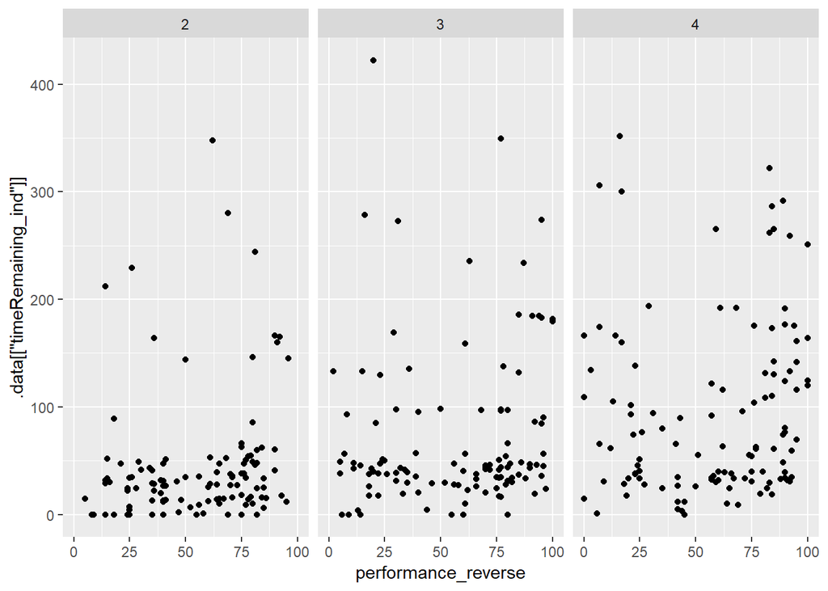

```r
# dependent<- "timeRemaining_ind"

plot_data_ind <- ind_data %>%
  select(Performance,
         params$dependent_response_ind,
         SessionOrder)%>%
  mutate(performance_reverse = 100 - Performance)

ggplot(data = plot_data_ind, aes(x = performance_reverse, y = .data[[params$dependent_response_ind]])) +
  geom_point() +
  facet_grid( . ~ SessionOrder)
```

No obvious patterns. The varience seems to increase over time. No obvious violation of monotonic relationship.

```r
for (my_session in c(2:4)) {

  plot_data_ind <- ind_data %>%
  select(Performance,
         params$dependent_response_ind,
         SessionOrder) %>%
  mutate(performance_reverse = 100 - Performance) %>%
  filter(SessionOrder == my_session)

  N_paris<- length(plot_data_ind[[params$dependent_response_ind]])

  print(paste("Correltation: Session =", my_session))

  print(paste("Pairs:", N_paris, ", Degree of Freedom:", N_paris-2))

  print(cor.test(y = plot_data_ind[[params$dependent_response_ind]], x = plot_data_ind[["performance_reverse"]], method = "spearman"))
  }
```

```
## [1] "Correltation: Session = 2"
## [1] "Pairs: 117 , Degree of Freedom: 115"
```

```
##
##  Spearman's rank correlation rho
##
## data:  plot_data_ind[["performance_reverse"]] and plot_data_ind[[params$dependent_response_ind]]
## S = 199650, p-value = 0.006125
## alternative hypothesis: true rho is not equal to 0
## sample estimates:
##       rho
## 0.2520093
##
## [1] "Correltation: Session = 3"
## [1] "Pairs: 117 , Degree of Freedom: 115"
```

```
##
##  Spearman's rank correlation rho
##
## data:  plot_data_ind[["performance_reverse"]] and plot_data_ind[[params$dependent_response_ind]]
## S = 224950, p-value = 0.0905
## alternative hypothesis: true rho is not equal to 0
## sample estimates:
##      rho
## 0.157211
##
## [1] "Correltation: Session = 4"
## [1] "Pairs: 117 , Degree of Freedom: 115"
```

```
##
##  Spearman's rank correlation rho
##
## data:  plot_data_ind[["performance_reverse"]] and plot_data_ind[[params$dependent_response_ind]]
## S = 215400, p-value = 0.03706
## alternative hypothesis: true rho is not equal to 0
## sample estimates:
##       rho
## 0.1930207
```

The results show a **significant** correlation betweent time remaining and self reported performance (reversed) session 2 and 4. Specifically, as self-reported performance increases, the time remaining increase. This indicates a correct self examination. There is a **marginally significant** correlation for session 3

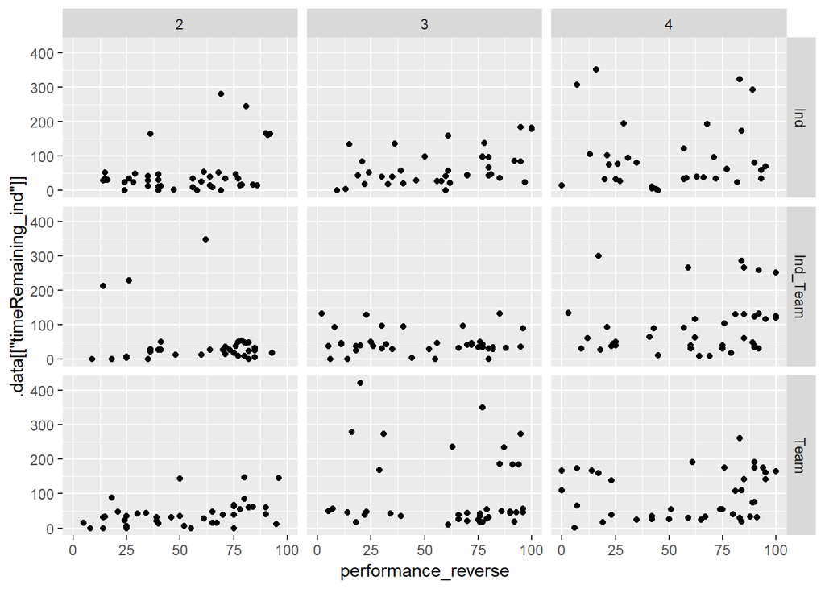

```r
# dependent<- "timeRemaining_ind"

plot_data_ind <- ind_data %>%
  select(Performance,
         params$dependent_response_ind,
         Target,
         SessionOrder)%>%
  mutate(performance_reverse = 100 - Performance)

ggplot(data = plot_data_ind, aes(x = performance_reverse, y = .data[[params$dependent_response_ind]])) +
  geom_point() +
  facet_grid( Target ~ SessionOrder)
```

No obious pattern. The varience may increase over time. No obvious violation of monotonic relationship.

```r
for (my_session in c(2:4)) {
  for (my_target in c("Ind", "Team", "Ind_Team")) {
    plot_data_ind <- ind_data %>%
      select(Performance,
             params$dependent_response_ind,
             SessionOrder,
             Target) %>%
      mutate(performance_reverse = 100 - Performance) %>%
      filter(Target == my_target, SessionOrder == my_session)

    N_paris<- length(plot_data_ind[[params$dependent_response_ind]])

  test<- cor.test(y = plot_data_ind[[params$dependent_response_ind]], x = plot_data_ind[["performance_reverse"]], method = "spearman")

  if(test$p.value < 0.1){
    print(paste("Correltation: Condition =", my_target,",", "Session =", my_session))

    print(paste("Pairs:", N_paris, ", Degree of Freedom:", N_paris-2))
  }
  print(test$p.value)
  }
}
```

```
## [1] 0.2395841
```

```
## [1] "Correltation: Condition = Team , Session = 2"
## [1] "Pairs: 39 , Degree of Freedom: 37"
## [1] 0.006118239
```

```
## [1] 0.2992335
```

```
## [1] "Correltation: Condition = Ind , Session = 3"
## [1] "Pairs: 39 , Degree of Freedom: 37"
## [1] 0.005686137
```

```
## [1] 0.8452173
```

```
## [1] 0.6739207
```

```
## [1] 0.8114218
```

```
## [1] 0.1508413
```

```
## [1] 0.1029924
```

There was a **significant** correltation in the following condition and session combinations: Condition = Team , Session = 2 Condition = Ind , Session = 3

```r
my_target<- "Team"
my_session<- 2

plot_data_ind <- ind_data %>%
      select(Performance,
             params$dependent_response_ind,
             SessionOrder,
             Target) %>%
      mutate(performance_reverse = 100 - Performance) %>%
      filter(Target == my_target, SessionOrder == my_session)

N_paris<- length(plot_data_ind[[params$dependent_response_ind]])

print(paste("Correltation: Condition =", my_target,",", "Session =", my_session))
```

```
## [1] "Correltation: Condition = Team , Session = 2"
```

```r
print(paste("Pairs:", N_paris, ", Degree of Freedom:", N_paris-2))
```

```
## [1] "Pairs: 39 , Degree of Freedom: 37"
```

```r
test<- cor.test(y = plot_data_ind[[params$dependent_response_ind]], x = plot_data_ind[["performance_reverse"]], method = "spearman")
print(test)
```

```
##
##  Spearman's rank correlation rho
##
## data:  plot_data_ind[["performance_reverse"]] and plot_data_ind[[params$dependent_response_ind]]
## S = 5618.7, p-value = 0.006118
## alternative hypothesis: true rho is not equal to 0
## sample estimates:
##       rho
## 0.4313072
```

```r
#----

my_target<- "Ind"
my_session<- 3

plot_data_ind <- ind_data %>%
      select(Performance,
             params$dependent_response_ind,
             SessionOrder,
             Target) %>%
      mutate(performance_reverse = 100 - Performance) %>%
      filter(Target == my_target, SessionOrder == my_session)

N_paris<- length(plot_data_ind[[params$dependent_response_ind]])

print(paste("Correltation: Condition =", my_target,",", "Session =", my_session))
```

```
## [1] "Correltation: Condition = Ind , Session = 3"
```

```r
print(paste("Pairs:", N_paris, ", Degree of Freedom:", N_paris-2))
```

```
## [1] "Pairs: 39 , Degree of Freedom: 37"
```

```r
test<- cor.test(y = plot_data_ind[[params$dependent_response_ind]], x = plot_data_ind[["performance_reverse"]], method = "spearman")
print(test)
```

```
##
##  Spearman's rank correlation rho
##
## data:  plot_data_ind[["performance_reverse"]] and plot_data_ind[[params$dependent_response_ind]]
## S = 5585.2, p-value = 0.005686
## alternative hypothesis: true rho is not equal to 0
## sample estimates:
##      rho
## 0.434699
```

The both **significant** correlations are positive. Indicating that as their self-reported performance increased, so did their time remaining. This is the case for Team in session 2, and for Individual in Session 3.

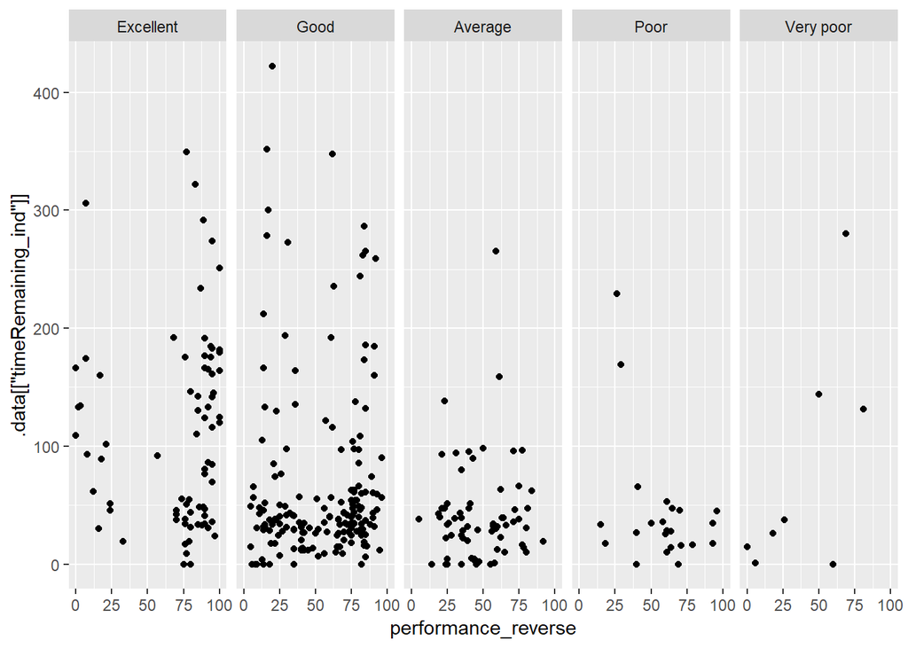

```r
# dependent <- "timeRemaining_ind"
plot_data_ind <- ind_data %>%
  select(Performance,
         params$dependent_response_ind,
         My_Performance) %>%
  mutate(performance_reverse = 100 - Performance) %>%
  mutate(My_Performance_f = factor(.data[["My_Performance"]], levels = c("Excellent", "Good", "Average", "Poor", "Very poor"))) # This mutate column was generated to order the facet groups.

ggplot(data = plot_data_ind, aes(x = performance_reverse, y = .data[[params$dependent_response_ind]])) +
  geom_point() +
  facet_grid(. ~ My_Performance_f)
```

Overally, it looks like most participants rated their performance as Good or average. Few pariticpants said their performance was Very poor. There were a decent number of participants that said their performance was Average or Excellent. No obvious violation of monotonic relationship.

```r
for (ind_rating in c("Excellent", "Good", "Average", "Poor", "Very poor")) {
  plot_data_ind <- ind_data %>%
        select(Performance,
               params$dependent_response_ind,
               My_Performance) %>%
        mutate(performance_reverse = 100 - Performance)%>%
        filter(My_Performance == ind_rating)

  N_paris<- length(plot_data_ind[[params$dependent_response_ind]])

  print(paste("Correltation: My_rating =", ind_rating))

  print(paste("Pairs:", N_paris, ", Degree of Freedom:", N_paris-2))

  test<- cor.test(y = plot_data_ind[[params$dependent_response_ind]], x = plot_data_ind[["performance_reverse"]], method = "spearman")

  print(test)
}
```

```
## [1] "Correltation: My_rating = Excellent"
## [1] "Pairs: 77 , Degree of Freedom: 75"
```

```
##
##  Spearman's rank correlation rho
##
## data:  plot_data_ind[["performance_reverse"]] and plot_data_ind[[params$dependent_response_ind]]
## S = 59671, p-value = 0.05963
## alternative hypothesis: true rho is not equal to 0
## sample estimates:
##       rho
## 0.2156428
##
## [1] "Correltation: My_rating = Good"
## [1] "Pairs: 175 , Degree of Freedom: 173"
```

```
##
##  Spearman's rank correlation rho
##
## data:  plot_data_ind[["performance_reverse"]] and plot_data_ind[[params$dependent_response_ind]]
## S = 750740, p-value = 0.035
## alternative hypothesis: true rho is not equal to 0
## sample estimates:
##       rho
## 0.1594985
##
## [1] "Correltation: My_rating = Average"
## [1] "Pairs: 68 , Degree of Freedom: 66"
```

```
##
##  Spearman's rank correlation rho
##
## data:  plot_data_ind[["performance_reverse"]] and plot_data_ind[[params$dependent_response_ind]]
## S = 51515, p-value = 0.892
## alternative hypothesis: true rho is not equal to 0
## sample estimates:
##       rho
## 0.0167825
##
## [1] "Correltation: My_rating = Poor"
## [1] "Pairs: 23 , Degree of Freedom: 21"
```

```
##
##  Spearman's rank correlation rho
##
## data:  plot_data_ind[["performance_reverse"]] and plot_data_ind[[params$dependent_response_ind]]
## S = 2423.7, p-value = 0.3664
## alternative hypothesis: true rho is not equal to 0
## sample estimates:
##        rho
## -0.1974762
##
## [1] "Correltation: My_rating = Very poor"
## [1] "Pairs: 8 , Degree of Freedom: 6"
##
##  Spearman's rank correlation rho
##
## data:  plot_data_ind[["performance_reverse"]] and plot_data_ind[[params$dependent_response_ind]]
## S = 40, p-value = 0.1966
## alternative hypothesis: true rho is not equal to 0
## sample estimates:
##       rho
## 0.5238095
```

The results showed a **signficant** correltation between time remaining and self-reported performance (resverse) for participants who reported their performance as “Good”, indicating a positive relationship. This suggest that participants correctly perceived their performance. There was a **marginally significant** positive correltation for participant who reported their performance as “Excellent”.

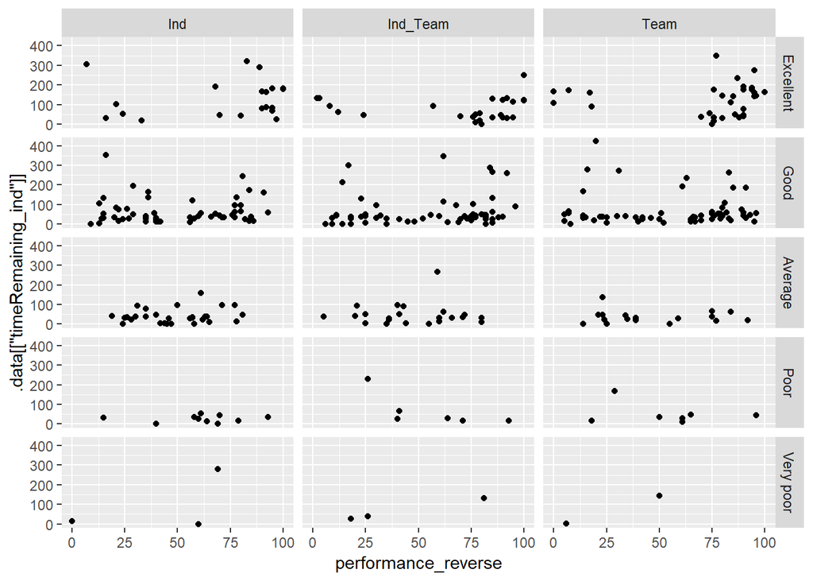

```r
# dependent<- "timeRemaining_ind"

plot_data_ind <- ind_data %>%
  select(Performance,
         params$dependent_response_ind,
         My_Performance,
         Target) %>%
  mutate(performance_reverse = 100 - Performance)%>%
  mutate(My_Performance_f = factor(.data[["My_Performance"]], levels = c("Excellent", "Good", "Average", "Poor", "Very poor"))) # This mutate column was generated to order the facet groups.

ggplot(data = plot_data_ind, aes(x = performance_reverse, y = .data[[params$dependent_response_ind]])) +
  geom_point() +
  facet_grid(My_Performance_f ~ Target)
```

When grouped by Target, the most obvious correlations appear when participants rated their performance as excellent. There may be some correlations with participants who rated their performance as good. No obvious violation of monotonic relationship.

```r
for (ind_rating in c("Excellent", "Good", "Average", "Poor", "Very poor")) {
  for (my_target in c("Ind", "Team", "Ind_Team")) {
    plot_data_ind <- ind_data %>%
        select(Performance,
               params$dependent_response_ind,
               My_Performance,
               Target) %>%
        mutate(performance_reverse = 100 - Performance)%>%
        filter(My_Performance == ind_rating, Target == my_target)

    N_paris<- length(plot_data_ind[[params$dependent_response_ind]])

    test<- cor.test(y = plot_data_ind[[params$dependent_response_ind]], x = plot_data_ind[["performance_reverse"]], method = "spearman")

    if(test$p.value < 0.1){
      print(paste("Correltation: Condition =", my_target, ", Rated_performance =", ind_rating))
      print(paste("Pairs:", N_paris, ", Degree of Freedom:", N_paris-2))
    }
    print(test$p.value)
  }
}
```

```
## [1] 0.6903753
```

```
## [1] 0.1312924
```

```
## [1] 0.5948643
```

```
## [1] 0.2575266
```

```
## [1] 0.3498438
```

```
## [1] 0.1062974
```

```
## [1] 0.5069652
```

```
## [1] 0.8478523
```

```
## [1] 0.6926457
## [1] 0.8916388
```

```
## [1] 0.6990458
## [1] 0.1027778
## [1] 1
## [1] 1
## [1] 0.3333333
```

Results showed no significant or marginally significant correltations.

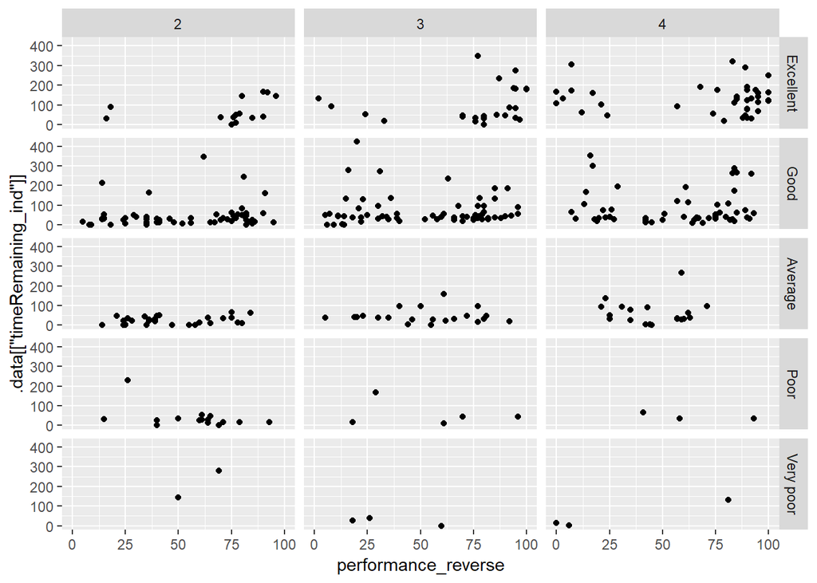

```r
# dependent<- "timeRemaining_ind"

plot_data_ind <- ind_data %>%
  select(Performance,
         params$dependent_response_ind,
         My_Performance,
         SessionOrder) %>%
  mutate(performance_reverse = 100 - Performance)%>%
  mutate(My_Performance_f = factor(.data[["My_Performance"]], levels = c("Excellent", "Good", "Average", "Poor", "Very poor"))) # This mutate column was generated to order the facet groups.

ggplot(data = plot_data_ind, aes(x = performance_reverse, y = .data[[params$dependent_response_ind]])) +
  geom_point() +
  facet_grid(My_Performance_f ~ SessionOrder)
```

No obvious pattern, there maybe a correlation for individuals who rated their performance as excellent. No obvious violation of monotonic relationship.

```r
for (ind_rating in c("Excellent", "Good", "Average", "Poor", "Very poor")) {
  for (my_session in c(2:4)) {
    plot_data_ind <- ind_data %>%
        select(Performance,
               params$dependent_response_ind,
               My_Performance,
               SessionOrder) %>%
        mutate(performance_reverse = 100 - Performance)%>%
        filter(My_Performance == ind_rating, SessionOrder == my_session)

    N_paris<- length(plot_data_ind[[params$dependent_response_ind]])

    test<- cor.test(y = plot_data_ind[[params$dependent_response_ind]], x = plot_data_ind[["performance_reverse"]], method = "spearman")

    if(test$p.value < 0.1){
      print(paste("Correltation: Session =", my_session, ", Rated_performance =", ind_rating))
      print(paste("Pairs:", N_paris, ", Degree of Freedom:", N_paris-2))
    }
    print(test$p.value)
  }
}
```

```
## [1] "Correltation: Session = 2 , Rated_performance = Excellent"
## [1] "Pairs: 14 , Degree of Freedom: 12"
## [1] 0.02625537
```

```
## [1] 0.1841258
```

```
## [1] 0.9711162
```

```
## [1] 0.1055237
```

```
## [1] 0.3433558
```

```
## [1] 0.5738925
```

```
## [1] 0.1529255
```

```
## [1] 0.4925937
```

```
## [1] 0.6674608
```

```
## [1] 0.1066444
## [1] 0.95
## [1] 0.3333333
## [1] 1
## [1] 1
## [1] 1
```

**Significant** results in the following: Session = 2 , Rated_performance = Excellent

```r
ind_rating<- "Excellent"
my_session<- 2

plot_data_ind <- ind_data %>%
        select(Performance,
               params$dependent_response_ind,
               My_Performance,
               SessionOrder) %>%
        mutate(performance_reverse = 100 - Performance)%>%
        filter(My_Performance == ind_rating, SessionOrder == my_session)

N_paris<- length(plot_data_ind[[params$dependent_response_ind]])

    test<- cor.test(y = plot_data_ind[[params$dependent_response_ind]], x = plot_data_ind[["performance_reverse"]], method = "spearman")
    if(test$p.value < 0.1){
      print(paste("Correltation: Session =", my_session, ", Rated_performance =", ind_rating))
      print(paste("Pairs:", N_paris, ", Degree of Freedom:", N_paris-2))
    }
```

```
## [1] "Correltation: Session = 2 , Rated_performance = Excellent"
## [1] "Pairs: 14 , Degree of Freedom: 12"
```

```r
    print(test)
```

```
##
##  Spearman's rank correlation rho
##
## data:  plot_data_ind[["performance_reverse"]] and plot_data_ind[[params$dependent_response_ind]]
## S = 186.41, p-value = 0.02626
## alternative hypothesis: true rho is not equal to 0
## sample estimates:
##       rho
## 0.5903098
```

**Significant** results in the following: Session = 2 , Rated_performance = Excellent

The results showed a positive correltation between the time remaining and the self-reported perforemance (reverse), indiciating a correct peception.

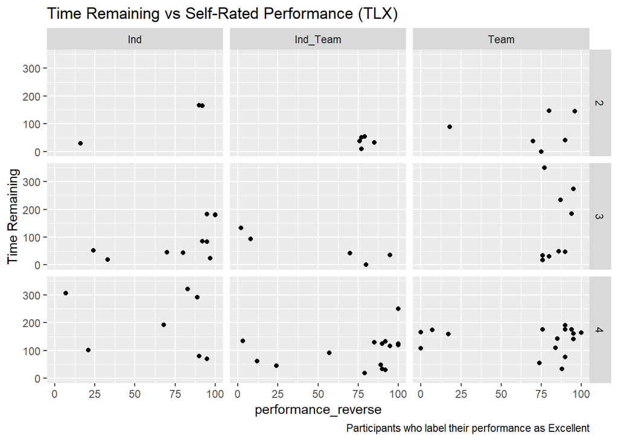

```r
# dependent<- "timeRemaining_ind"
y_lab_indep <- params$dependent_response_name_WithSpace

post_session_labled_performance<- "Excellent"
plot_data_ind <- ind_data %>%
  select(Performance,
         params$dependent_response_ind,
         My_Performance,
         SessionOrder,
         Target) %>%
  mutate(performance_reverse = 100 - Performance)%>%
  filter(My_Performance == post_session_labled_performance)

ggplot(data = plot_data_ind, aes(x = performance_reverse, y = .data[[params$dependent_response_ind]])) +
  geom_point() +
  labs(title = paste(y_lab_indep, "vs Self-Rated Performance (TLX)"), caption = paste("Participants who label their performance as", post_session_labled_performance) , y = y_lab_indep) +
  facet_grid(SessionOrder ~ Target)
```

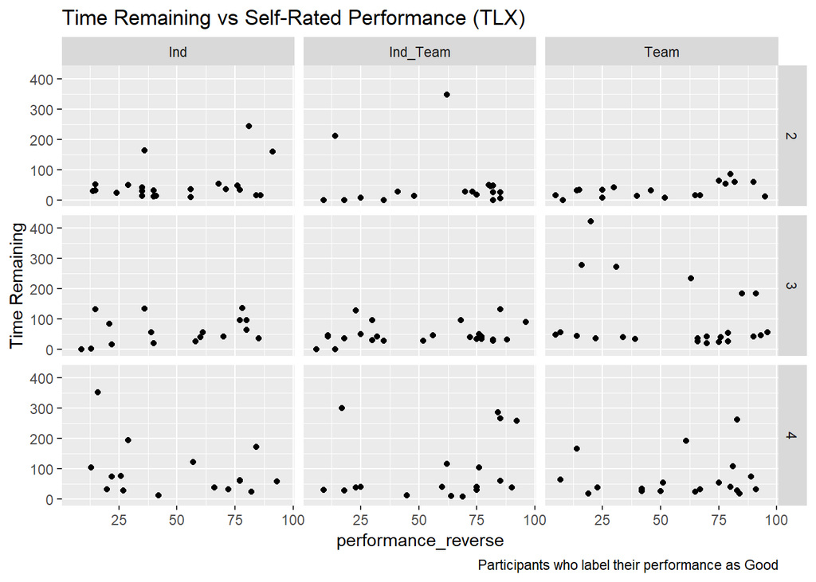

```r
post_session_labled_performance<- "Good"
plot_data_ind <- ind_data %>%
  select(Performance,
         params$dependent_response_ind,
         My_Performance,
         SessionOrder,
         Target) %>%
  mutate(performance_reverse = 100 - Performance)%>%
  filter(My_Performance == post_session_labled_performance)

ggplot(data = plot_data_ind, aes(x = performance_reverse, y = .data[[params$dependent_response_ind]])) +
  geom_point() +
  labs(title = paste(y_lab_indep, "vs Self-Rated Performance (TLX)"), caption = paste("Participants who label their performance as", post_session_labled_performance) , y = y_lab_indep) +
  facet_grid(SessionOrder ~ Target)
```

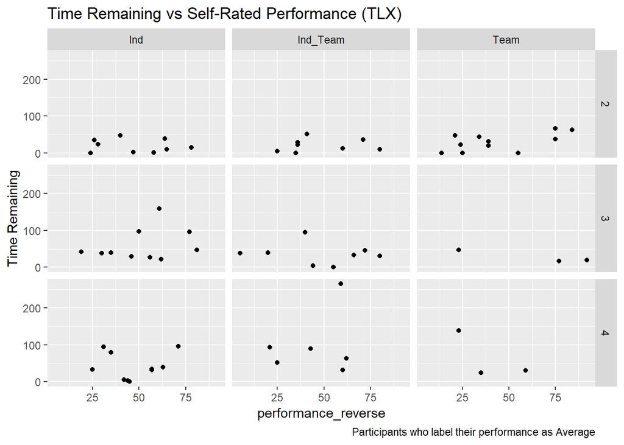

```r
post_session_labled_performance<- "Average"
plot_data_ind <- ind_data %>%
  select(Performance,
         params$dependent_response_ind,
         My_Performance,
         SessionOrder,
         Target) %>%
  mutate(performance_reverse = 100 - Performance)%>%
  filter(My_Performance == post_session_labled_performance)

ggplot(data = plot_data_ind, aes(x = performance_reverse, y = .data[[params$dependent_response_ind]])) +
  geom_point() +
  labs(title = paste(y_lab_indep, "vs Self-Rated Performance (TLX)"), caption = paste("Participants who label their performance as", post_session_labled_performance) , y = y_lab_indep) +
  facet_grid(SessionOrder ~ Target)
```

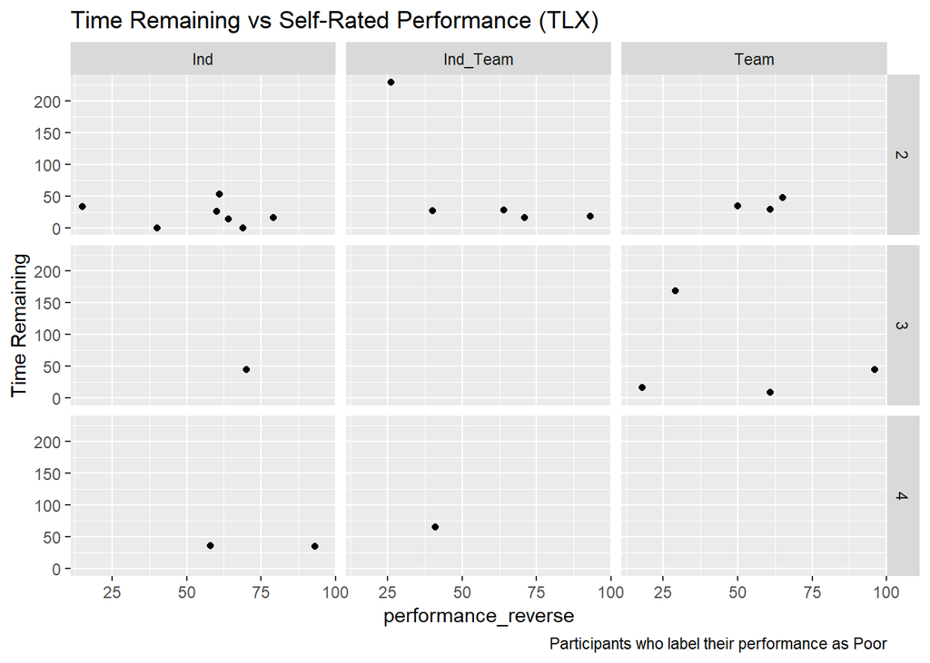

```r
post_session_labled_performance<- "Poor"
plot_data_ind <- ind_data %>%
  select(Performance,
         params$dependent_response_ind,
         My_Performance,
         SessionOrder,
         Target) %>%
  mutate(performance_reverse = 100 - Performance)%>%
  filter(My_Performance == post_session_labled_performance)

ggplot(data = plot_data_ind, aes(x = performance_reverse, y = .data[[params$dependent_response_ind]])) +
  geom_point() +
  labs(title = paste(y_lab_indep, "vs Self-Rated Performance (TLX)"), caption = paste("Participants who label their performance as", post_session_labled_performance) , y = y_lab_indep) +
  facet_grid(SessionOrder ~ Target)
```

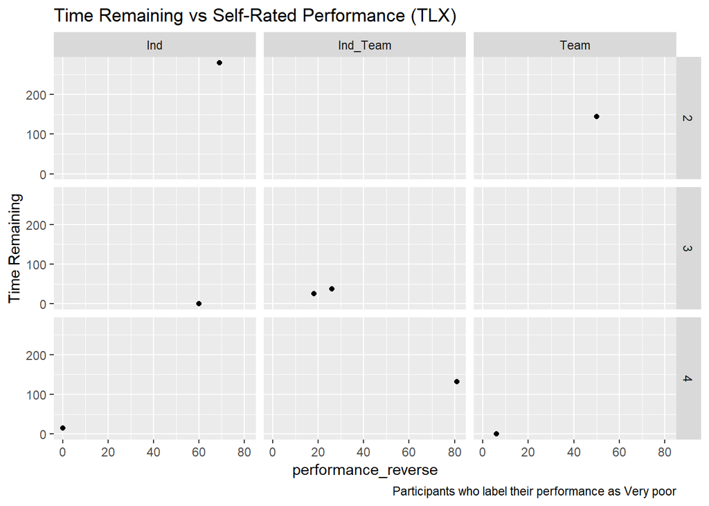

```r
post_session_labled_performance<- "Very poor"
plot_data_ind <- ind_data %>%
  select(Performance,
         params$dependent_response_ind,
         My_Performance,
         SessionOrder,
         Target) %>%
  mutate(performance_reverse = 100 - Performance)%>%
  filter(My_Performance == post_session_labled_performance)

ggplot(data = plot_data_ind, aes(x = performance_reverse, y = .data[[params$dependent_response_ind]])) +
  geom_point() +
  labs(title = paste(y_lab_indep, "vs Self-Rated Performance (TLX)"), caption = paste("Participants who label their performance as", post_session_labled_performance) , y = y_lab_indep) +
  facet_grid(SessionOrder ~ Target)
```

There seems to be no violation of monotonic relationship.

```r
for (ind_rating in c("Excellent", "Good", "Average", "Poor", "Very poor")) {
  for (my_target in c("Ind", "Team", "Ind_Team")) {
    for (my_session in c(2:4)) {
      plot_data_ind <- ind_data %>%
        select(Performance,
               params$dependent_response_ind,
               SessionOrder,
               Dominate.Strategy,
               My_Performance,
               Target,
               Player_ID) %>%
        mutate(performance_reverse = 100 - Performance)%>%
        filter(Target == my_target, My_Performance == ind_rating, SessionOrder == my_session)

      N_paris<- length(plot_data_ind[[params$dependent_response_ind]])

      if(length(plot_data_ind[[params$dependent_response_ind]]) < 3){
        message<- paste("There is less than 3 data point for the Condition =", my_target, ", Session =", my_session, ", Rated individual Performance =", ind_rating)
        print(message)
      } else {
        cor_test_results<- cor.test(x = plot_data_ind[["performance_reverse"]], y = plot_data_ind[[params$dependent_response_ind]], method = "spearman")

        if(cor_test_results$p.value < 0.1){
          print(paste("Correltation: Condition =", my_target, ", Session =", my_session, ", Rated individual Performance =", ind_rating))
          print(paste("Pairs:", N_paris, ", Degree of Freedom:", N_paris-2))
        }
        print(cor_test_results$p.value)
      }
    }
  }
}
```

```
## [1] 1
```

```
## [1] 0.1004221
## [1] 0.2
## [1] 0.4972222
```

```
## [1] 0.1523674
```

```
## [1] 0.5403306
```

```
## [1] 0.9347128
## [1] "Correltation: Condition = Ind_Team , Session = 3 , Rated individual Performance = Excellent"
## [1] "Pairs: 5 , Degree of Freedom: 3"
## [1] 0.08333333
```

```
## [1] 0.2981464
```

```
## [1] 0.5792921
```

```
## [1] 0.1839258
```

```
## [1] 0.3830667
```

```
## [1] "Correltation: Condition = Team , Session = 2 , Rated individual Performance = Good"
## [1] "Pairs: 18 , Degree of Freedom: 16"
## [1] 0.09755811
```

```
## [1] 0.4432345
```

```
## [1] 0.9119325
```

```
## [1] 0.4343066
```

```
## [1] 0.519024
```

```
## [1] 0.2012641
## [1] 0.8800926
## [1] 0.6075669
```

```
## [1] 0.7252501
```

```
## [1] 0.1983041
## [1] 1
## [1] 1
```

```
## [1] 0.3012666
## [1] 0.5364087
## [1] 0.5638889
## [1] 0.4444444
## [1] "There is less than 3 data point for the Condition = Ind , Session = 3 , Rated individual Performance = Poor"
## [1] "There is less than 3 data point for the Condition = Ind , Session = 4 , Rated individual Performance = Poor"
## [1] 1
## [1] 1
## [1] "There is less than 3 data point for the Condition = Team , Session = 4 , Rated individual Performance = Poor"
## [1] 0.1333333
## [1] "There is less than 3 data point for the Condition = Ind_Team , Session = 3 , Rated individual Performance = Poor"
## [1] "There is less than 3 data point for the Condition = Ind_Team , Session = 4 , Rated individual Performance = Poor"
## [1] "There is less than 3 data point for the Condition = Ind , Session = 2 , Rated individual Performance = Very poor"
## [1] "There is less than 3 data point for the Condition = Ind , Session = 3 , Rated individual Performance = Very poor"
## [1] "There is less than 3 data point for the Condition = Ind , Session = 4 , Rated individual Performance = Very poor"
## [1] "There is less than 3 data point for the Condition = Team , Session = 2 , Rated individual Performance = Very poor"
## [1] "There is less than 3 data point for the Condition = Team , Session = 3 , Rated individual Performance = Very poor"
## [1] "There is less than 3 data point for the Condition = Team , Session = 4 , Rated individual Performance = Very poor"
## [1] "There is less than 3 data point for the Condition = Ind_Team , Session = 2 , Rated individual Performance = Very poor"
## [1] "There is less than 3 data point for the Condition = Ind_Team , Session = 3 , Rated individual Performance = Very poor"
## [1] "There is less than 3 data point for the Condition = Ind_Team , Session = 4 , Rated individual Performance = Very poor"
```

The results show no significant correlations. The following correlations are **margnially significant**:

Condition = Ind_Team , Session = 3 , Rated individual Performance = Excellent Condition = Team , Session = 2 , Rated individual Performance = Good

```r
# dependent<- "timeRemaining_ind"
current_target<- "Ind_Team"
current_my_performance<-  "Excellent"
current_Session<- 3

plot_data_ind <- ind_data %>%
  select(Performance,
         params$dependent_response_ind,
         SessionOrder,
         Dominate.Strategy,
         My_Performance,
         Target,
         Player_ID) %>%
  mutate(performance_reverse = 100 - Performance) %>%
  filter(Target == current_target, My_Performance == current_my_performance, SessionOrder == current_Session)

N_paris<- length(plot_data_ind[[params$dependent_response_ind]])

print(paste("Correltation: Condition =", current_target, ", Session =", current_Session, ", Rated individual Performance =", current_my_performance))
```

```
## [1] "Correltation: Condition = Ind_Team , Session = 3 , Rated individual Performance = Excellent"
```

```r
print(paste("Pairs:", N_paris, ", Degree of Freedom:", N_paris-2))
```

```
## [1] "Pairs: 5 , Degree of Freedom: 3"
```

```r
cor.test(y = plot_data_ind[[params$dependent_response_ind]], x = plot_data_ind[["performance_reverse"]], method = "spearman")
```

```
##
##  Spearman's rank correlation rho
##
## data:  plot_data_ind[["performance_reverse"]] and plot_data_ind[[params$dependent_response_ind]]
## S = 38, p-value = 0.08333
## alternative hypothesis: true rho is not equal to 0
## sample estimates:
##  rho
## -0.9
```

```r
#----

# dependent<- "timeRemaining_ind"
current_target<- "Team"
current_my_performance<-  "Good"
current_Session<- 2

plot_data_ind <- ind_data %>%
  select(Performance,
         params$dependent_response_ind,
         SessionOrder,
         Dominate.Strategy,
         My_Performance,
         Target,
         Player_ID) %>%
  mutate(performance_reverse = 100 - Performance) %>%
  filter(Target == current_target, My_Performance == current_my_performance, SessionOrder == current_Session)

N_paris<- length(plot_data_ind[[params$dependent_response_ind]])

print(paste("Correltation: Condition =", current_target, ", Session =", current_Session, ", Rated individual Performance =", current_my_performance))
```

```
## [1] "Correltation: Condition = Team , Session = 2 , Rated individual Performance = Good"
```

```r
print(paste("Pairs:", N_paris, ", Degree of Freedom:", N_paris-2))
```

```
## [1] "Pairs: 18 , Degree of Freedom: 16"
```

```r
cor.test(y = plot_data_ind[[params$dependent_response_ind]], x = plot_data_ind[["performance_reverse"]], method = "spearman")
```

```
##
##  Spearman's rank correlation rho
##
## data:  plot_data_ind[["performance_reverse"]] and plot_data_ind[[params$dependent_response_ind]]
## S = 578.8, p-value = 0.09756
## alternative hypothesis: true rho is not equal to 0
## sample estimates:
##       rho
## 0.4026846
```

Condition = Ind_Team , Session = 3 , Rated individual Performance = Excellent, negative correlation Condition = Team , Session = 2 , Rated individual Performance = Good, positive correlation

## Summary

When grouping paired responses for timeraiming and performance (reverse) by Target, there was a **significant** positive correlation for in the Ind and Team condition.

When grouping paired responses for timeraiming and performance (reverse) by SessionOrder, there was a **significant** positive correltation in session 2 and 4. There was also a **marginally significant** correlation for session 3.

When grouping paired responses for timeraiming and performance (reverse) by SessionOrder and Target, there was a **significant** positive correltation for participants in Team in session 2, and for participant in Individual and Session 3.

When grouping paired responses for timeraiming and performance (reverse) by self-reported performance(e.g., good vs. poor), there was a **significant** positive correlation for participants who labeled their performance as “Good”. There was also a **marginally significant** positive correlation for participants who reported their performance as “Excellent”.

When grouping paired responses for timeraiming and performance (reverse) by self-reported performance(e.g., good vs. poor) and session order, there was a **significant** positive correlation for participants in session 2 that rated their performance as Excellent.

When grouping paired responses for timeraiming and performance (reverse) by self-reported performance(e.g., good vs. poor), Target, and session order, there was a **marginally significant** netgative correlation for pariticpnats in the Ind_Team condition, in session 3, with a self performance rating of “Excellent”. There was a **marginally significant** positive correlation for pariticpnats in the Team condition, in session 2, with a self performance rating of “Good”.